# Imputación_datos_perdidos

### Limpieza y configuración del entorno de trabajo

```r
rm(list = ls())
graphics.off()
cat("\014")
```

```r
options(scipen = 999)
options(digits = 3)
```

### Descripción de los datos

Los datos Risk.sav contiene la información financiera de más  
de 4000 clientes. El objetivo es predecir la variable riesgo.

#### Variable Dependiente o Target:

-RIESGO (0=Bajo, 1=Alto)

#### Variables Independentes o Predictoras:

-EDAD (Edad del cliente en años)  
-GENERO (Género del cliente,  
1=Masculino 2=Femenino)  
-EST_MARITAL (Estado civil del cliente,  
1=Casado 2=Soltero, 3=Otros)  
-HIJOS (Número de hijos del cliente)  
-INGRESO (Ingresos anuales familiares del  
cliente en dólares)  
-TARJETAS (Número de tarjetas de crédito)  
-PRESTAMO (Número de préstamos)  
-PAGO (Forma de pago, 1=mensual 2=semanal)  
-HIPOTECA (Cuenta con hipoteca, 1=No 2=Si)

#### Variable de identificación:

-ID (Código del cliente)

Importación de la base datos

```r
data <- read.csv("Risk.csv")
data<-data.frame(data)

head(data)
```

```
##       ID EDAD    GENERO EST_MARITAL HIJOS INGRESO TARJETAS PRESTAMOS    PAGO
## 1 100426   35 Masculino      Casado    NA   27933        1         1 Mensual
## 2 100771   45 Masculino      Casado     0   28840        1         0 Mensual
## 3 100607   40      <NA>      Casado     0   29816        2         0 Mensual
## 4 100608   40 Masculino      Casado     0   30273        1         0 Mensual
## 5 100773   NA Masculino      Casado     0   32977        2         1 Mensual
## 6 100734   44 Masculino      Casado     0   33454        1         1 Mensual
##   HIPOTECA RIESGO
## 1       Si   Bajo
## 2       Si   Alto
## 3       Si   Bajo
## 4       Si   Bajo
## 5       Si   Alto
## 6     <NA>   Alto
```

```r
dim(data)
```

```
## [1] 4117   11
```

Identificación de tipos de variables

```r
str(data)
```

```
## 'data.frame':    4117 obs. of  11 variables:
##  $ ID         : int  100426 100771 100607 100608 100773 100734 100462 100709 100572 100301 ...
##  $ EDAD       : int  35 45 40 40 NA 44 36 43 39 31 ...
##  $ GENERO     : chr  "Masculino" "Masculino" NA "Masculino" ...
##  $ EST_MARITAL: chr  "Casado" "Casado" "Casado" "Casado" ...
##  $ HIJOS      : int  NA 0 0 0 0 0 0 0 0 0 ...
##  $ INGRESO    : int  27933 28840 29816 30273 32977 33454 34288 36255 NA 39696 ...
##  $ TARJETAS   : int  1 1 2 1 2 1 1 2 2 1 ...
##  $ PRESTAMOS  : int  1 0 0 0 1 1 NA 1 0 NA ...
##  $ PAGO       : chr  "Mensual" "Mensual" "Mensual" "Mensual" ...
##  $ HIPOTECA   : chr  "Si" "Si" "Si" "Si" ...
##  $ RIESGO     : chr  "Bajo" "Alto" "Bajo" "Bajo" ...
```

Se elimina la variable ID dado que no representa importancia para el análisis.

```r
data<-data[,-1]
head(data)
```

```
##   EDAD    GENERO EST_MARITAL HIJOS INGRESO TARJETAS PRESTAMOS    PAGO HIPOTECA
## 1   35 Masculino      Casado    NA   27933        1         1 Mensual       Si
## 2   45 Masculino      Casado     0   28840        1         0 Mensual       Si
## 3   40      <NA>      Casado     0   29816        2         0 Mensual       Si
## 4   40 Masculino      Casado     0   30273        1         0 Mensual       Si
## 5   NA Masculino      Casado     0   32977        2         1 Mensual       Si
## 6   44 Masculino      Casado     0   33454        1         1 Mensual     <NA>
##   RIESGO
## 1   Bajo
## 2   Alto
## 3   Bajo
## 4   Bajo
## 5   Alto
## 6   Alto
```

Identificación de variables con valores perdidos dado que pueden generar problemas en el análisis.  
Estas pueden ser de tipo MCAR, MAR o MNAR.

```r
variables_con_Valores_perdidos <- colnames(data)[colSums(is.na(data)) > 0]
variables_con_Valores_perdidos
```

```
## [1] "EDAD"        "GENERO"      "EST_MARITAL" "HIJOS"       "INGRESO"
## [6] "TARJETAS"    "PRESTAMOS"   "PAGO"        "HIPOTECA"
```

Porcentaje de valores perdidos por variable

```r
sum(complete.cases(data$EDAD)==FALSE)/dim(data)[1] * 100
```

```
## [1] 9.42
```

```r
sum(complete.cases(data$GENERO)==FALSE)/dim(data)[1] * 100
```

```
## [1] 10.3
```

```r
sum(complete.cases(data$EST_MARITAL)==FALSE)/dim(data)[1] * 100
```

```
## [1] 9.98
```

```r
sum(complete.cases(data$HIJOS)==FALSE)/dim(data)[1] * 100
```

```
## [1] 9.93
```

```r
sum(complete.cases(data$INGRESO)==FALSE)/dim(data)[1] * 100
```

```
## [1] 10.1
```

```r
sum(complete.cases(data$TARJETAS)==FALSE)/dim(data)[1] * 100
```

```
## [1] 10.4
```

```r
sum(complete.cases(data$PRESTAMOS)==FALSE)/dim(data)[1] * 100
```

```
## [1] 9.59
```

```r
sum(complete.cases(data$PAGO)==FALSE)/dim(data)[1] * 100
```

```
## [1] 9.96
```

```r
sum(complete.cases(data$HIPOTECA)==FALSE)/dim(data)[1] * 100
```

```
## [1] 9.06
```

Otra forma

```r
porcentaje_perdidos_todos <- colSums(is.na(data[1:dim(data)[2]-1])) / nrow(data) * 100
porcentaje_perdidos_todos
```

```
##        EDAD      GENERO EST_MARITAL       HIJOS     INGRESO    TARJETAS
##        9.42       10.27        9.98        9.93       10.06       10.42
##   PRESTAMOS        PAGO    HIPOTECA
##        9.59        9.96        9.06
```

De manera gráfica

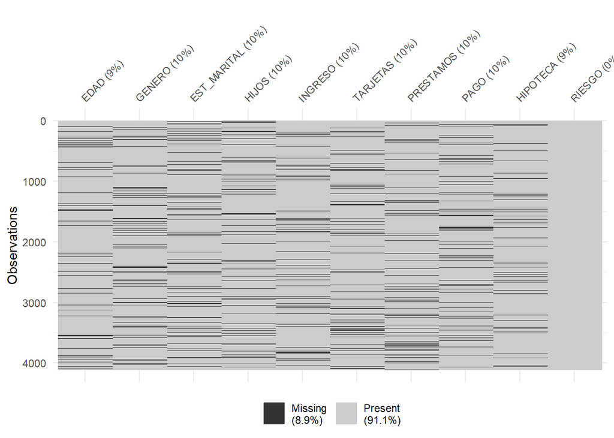

```r
library(naniar)
vis_miss(data)
```

Conclusión en todas las variables se identifican valores perdidos excepto en riesgo que es el target.

### IMPUTACIÓN DE DATOS

Para variables categóricas una imputación básica es la moda

```r
Mode <- function(x) {
  ux <- unique(x)
  ux[which.max(tabulate(match(x, ux)))]
}
```

```r
str(data)
```

```
## 'data.frame':    4117 obs. of  10 variables:
##  $ EDAD       : int  35 45 40 40 NA 44 36 43 39 31 ...
##  $ GENERO     : chr  "Masculino" "Masculino" NA "Masculino" ...
##  $ EST_MARITAL: chr  "Casado" "Casado" "Casado" "Casado" ...
##  $ HIJOS      : int  NA 0 0 0 0 0 0 0 0 0 ...
##  $ INGRESO    : int  27933 28840 29816 30273 32977 33454 34288 36255 NA 39696 ...
##  $ TARJETAS   : int  1 1 2 1 2 1 1 2 2 1 ...
##  $ PRESTAMOS  : int  1 0 0 0 1 1 NA 1 0 NA ...
##  $ PAGO       : chr  "Mensual" "Mensual" "Mensual" "Mensual" ...
##  $ HIPOTECA   : chr  "Si" "Si" "Si" "Si" ...
##  $ RIESGO     : chr  "Bajo" "Alto" "Bajo" "Bajo" ...
```

```r
Imputados_riesgos<-data
head(Imputados_riesgos)
```

```
##   EDAD    GENERO EST_MARITAL HIJOS INGRESO TARJETAS PRESTAMOS    PAGO HIPOTECA
## 1   35 Masculino      Casado    NA   27933        1         1 Mensual       Si
## 2   45 Masculino      Casado     0   28840        1         0 Mensual       Si
## 3   40      <NA>      Casado     0   29816        2         0 Mensual       Si
## 4   40 Masculino      Casado     0   30273        1         0 Mensual       Si
## 5   NA Masculino      Casado     0   32977        2         1 Mensual       Si
## 6   44 Masculino      Casado     0   33454        1         1 Mensual     <NA>
##   RIESGO
## 1   Bajo
## 2   Alto
## 3   Bajo
## 4   Bajo
## 5   Alto
## 6   Alto
```

```r
Imputados_riesgos$GENERO <- ifelse(is.na(Imputados_riesgos$GENERO),
                                   Mode(Imputados_riesgos$GENERO),
                                   Imputados_riesgos$GENERO)

Imputados_riesgos$EST_MARITAL <- ifelse(is.na(Imputados_riesgos$EST_MARITAL),
                                        Mode(Imputados_riesgos$EST_MARITAL),
                                        Imputados_riesgos$EST_MARITAL)

Imputados_riesgos$PAGO <- ifelse(is.na(Imputados_riesgos$PAGO),
                                 Mode(Imputados_riesgos$PAGO),
                                 Imputados_riesgos$PAGO)

Imputados_riesgos$HIPOTECA <- ifelse(is.na(Imputados_riesgos$HIPOTECA),
                                     Mode(Imputados_riesgos$HIPOTECA),
                                     Imputados_riesgos$HIPOTECA)
```

### Imputando los cuantitativos por la media / EDAD, HIJOS, INGRESO, TARJETAS, PRESTAMOS

```r
Imputados_riesgos$EDAD <- ifelse(is.na(Imputados_riesgos$EDAD),
                                 mean(Imputados_riesgos$EDAD, na.rm = TRUE),
                                 Imputados_riesgos$EDAD)

Imputados_riesgos$HIJOS <- ifelse(is.na(Imputados_riesgos$HIJOS),
                                  mean(Imputados_riesgos$HIJOS, na.rm = TRUE),
                                  Imputados_riesgos$HIJOS)

Imputados_riesgos$INGRESO <- ifelse(is.na(Imputados_riesgos$INGRESO),
                                    mean(Imputados_riesgos$INGRESO, na.rm = TRUE),
                                    Imputados_riesgos$INGRESO)

Imputados_riesgos$TARJETAS <- ifelse(is.na(Imputados_riesgos$TARJETAS),
                                     mean(Imputados_riesgos$TARJETAS, na.rm = TRUE),
                                     Imputados_riesgos$TARJETAS)

Imputados_riesgos$PRESTAMOS <- ifelse(is.na(Imputados_riesgos$PRESTAMOS),
                                      mean(Imputados_riesgos$PRESTAMOS, na.rm = TRUE),
                                      Imputados_riesgos$PRESTAMOS)
```

Verificando si los datos han sido imputados correctamente

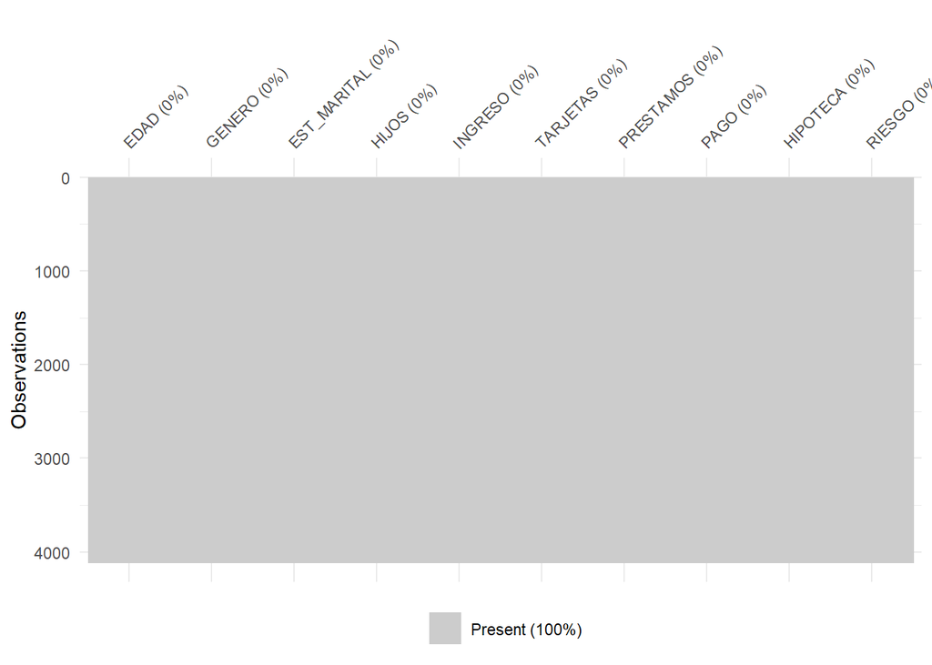

```r
vis_miss(Imputados_riesgos)
```